# Homework 06: Data wrangling wrap up

Stephen Chignell

November 8, 2018

## Goals

Complete two of six possible tasks on data wrangling!

## Task 1: Character data

The following exercises explore a number of tools for wrangling strings.

First, we load `stringr` package for working with character strings

```r
suppressMessages(library(stringr))
suppressMessages(library(stringi))
suppressMessages(library(dplyr))
```

### Exercise 14.2.5

**[1]** In code that doesn’t use stringr, you’ll often see paste() and paste0(). What’s the difference between the two functions? What stringr function are they equivalent to? How do the functions differ in their handling of NA?

*Answer:*

- `paste()` converts vectors to characters and concatenates them based on a rule (in this case, a specific separator).
- `paste0()` accomplishes the same task, but assumes that sep = “”, so it can be quicker option if the data is in the correct format.

We see this in the following examples:

```r
# use sep for individual character strings
paste("a", "b", sep = "")
```

```
## [1] "ab"
```

```r
# use collapse for one string
x <- c("a", "b")
paste(x, collapse = "")
```

```
## [1] "ab"
```

```r
# use paste0() to assume "" as separator
paste0("a", "b")
```

```
## [1] "ab"
```

```r
# here we see that this is equivalent to `str_c` from stringr
str_c("a", "b")
```

```
## [1] "ab"
```

- With `str_c`, when a missing value is combined with another string, the result will be missing (NA). You can then use str_replace_na() to convert NA to “NA”
- `paste()`, on the otherhand, coerces the missing value (NA) to “NA” automatically.

**[2]** In your own words, describe the difference between the sep and collapse arguments to str_c().

*Answer:*

- “sep”" is used to control how individual character strings are to be separated
- “collapse” is used to change a vector of strings into a single string.

**[3]** Use str_length() and str_sub() to extract the middle character from a string. What will you do if the string has an even number of characters?

*Answer:*

```r
odd <- "Steve"
str_length(odd)
```

```
## [1] 5
```

```r
# Middle character of 5 is 3
str_sub(odd, 3,3)
```

```
## [1] "e"
```

```r
even <- "Steve!"
str_length(even)
```

```
## [1] 6
```

```r
# Middle two characters of 6 is 3 and 4
str_sub(odd, 3,4)
```

```
## [1] "ev"
```

**[4]** What does str_wrap() do? When might you want to use it?

*Answer:*

`str_wrap()` is a wrapper around stringi::stri_wrap() which implements the Knuth-Plass paragraph wrapping algorithm. It reformats a character vector of strings based on a specificie dwidth and indentation and/or exdentation.

This would be useful for customizing the display of large blocks of texts, to ensure they are printed as nice, legible paragraphs.

**[5]** What does str_trim() do? What’s the opposite of str_trim()?

*Answer:*

- `str_trim()` removes whitespace from start and end of string. The “side” argument specifics the side on which to remove whitespace (left, right, or both).
- `str_pad()` does the opposite, adding whitespace based on specified width and side.

**[6]** Write a function that turns (e.g.) a vector c(“a”, “b”, “c”) into the string a, b, and c. Think carefully about what it should do if given a vector of length 0, 1, or 2.

*Answer:*

```r
a <- c("a", "b", "c")
a
```

```
## [1] "a" "b" "c"
```

```r
vec2str <- function(x){
  if (length(x) <=1)  {
    x
  }else{
    str_c(x, collapse = ", ")
  }
}
vec2str(c("a", "b", "c"))
```

```
## [1] "a, b, c"
```

### Exercise 14.3.1.1

**[1]** Explain why each of these strings don’t match a `\`:

*Answer:*

- `"\"` This has a special behavior assigned to it already (i.e. escape)
- `"\\"` This escapes the escape behavior to create regular expression
- `"\\\"` This is a regular expression that requires a string, which must also be escaped in order to match a literal `\`.

**[2]** How would you match the sequence `"'\?`

*Answer:*

```r
z <- "\"\'\\?"
z
```

```
## [1] "\"'\\?"
```

```r
str_view("?", "\\?")
```

[interactive chart not shown]

**[3]** What patterns will the regular expression ...... match? How would you represent it as a string?

*Answer:*

It will match the pattern: “.wildcard.wildcard.wildcard”

```r
string <- "\\..\\..\\.."
string
```

```
## [1] "\\..\\..\\.."
```

```r
str_view(".h.h.hurry!", "\\..\\..\\..")
```

[interactive chart not shown]

### Exercise 14.3.2.1

**[1]** How would you match the literal string “$^$”?

*Answer:*

```r
#example
str_view("F$^$@!", pattern = "\\$\\^\\$", match = TRUE)
```

[interactive chart not shown]

**[2]** Given the corpus of common words in stringr::words, create regular expressions that find all words that:

*Answer:*

Start with “y”.

```r
str_view(words, pattern = "^y", match = TRUE)
```

[interactive chart not shown]

End with “x”

```r
str_view(words, pattern = "$x", match = TRUE)
```

[interactive chart not shown]

Are exactly three letters long. (Don’t cheat by using `str_length()`!)

```r
str_view(words, pattern = "^...$", match = TRUE)
```

[interactive chart not shown]

Have seven letters or more.

```r
str_view(words, pattern = "^.......", match = TRUE)
```

[interactive chart not shown]

### Exercise 14.3.3.1

**[1]** Create regular expressions to find all words that:

*Answer:*

```r
# Start with a vowel.
str_view(words, pattern = "^[aeiou]", match = TRUE)
```

[interactive chart not shown]

```r
# That only contain consonants. (Hint: thinking about matching “not”-vowels.)
str_view(words, pattern = "^[^aeiou]*$", match = TRUE)
```

[interactive chart not shown]

```r
# End with ed, but not with eed.
str_view(words, pattern = "[^e]ed$", match = TRUE)
```

[interactive chart not shown]

```r
# End with ing or ise.
str_view(words, pattern = "(ing|ise)$", match = TRUE)
```

[interactive chart not shown]

**[2]** Empirically verify the rule “i before e except after c”.

*Answer:*

```r
# NOT SURE
str_view(words, pattern = "cie", match = TRUE)
```

[interactive chart not shown]

```r
str_view(words, pattern = "(c).*(i).*(e)*", match = TRUE)
```

[interactive chart not shown]

**[3]** Is “q” always followed by a “u”?

*Answer:*

```r
str_view(words, pattern = "q[^u]", match = TRUE)
```

[interactive chart not shown]

Yes, “u” always follows “q” in the *words* dataset.

**[4]** Write a regular expression that matches a word if it’s probably written in British English, not American English. Note: rules based on the [Oxford dictionaries British and American English spelling](https://en.oxforddictionaries.com/spelling/british-and-spelling)

*Answer:*

```r
str_view(words, pattern = "[^aeiou]re$|[^aeiou]our$|[^aeiou]ise$|[^aeiou]yse$|[aeiou]ll[aeiou]$|[aeiou]ence$|[aeiou]ogue$|ae|oe", match = TRUE)
```

[interactive chart not shown]

**[5]** Create a regular expression that will match telephone numbers as commonly written in your country.

*Answer:* In the United States, phone numbers are written in the following way: 1-(XXX)-XXX-XXXX

```r
# example
str_view("1-(555)-541-2679", pattern = "1-\\([0-9][0-9][0-9]\\)-[0-9][0-9][0-9]-[0-9][0-9][0-9][0-9]", match = TRUE)
```

[interactive chart not shown]

### Exercise 14.3.4.1

**[1]** Describe the equivalents of ?, +, * in {m,n} form.

*Answer:* Let’s use the roman numerals provided by the R for Data Science Strings chapter:

```r
w <- "1888 is the longest year in Roman numerals: MDCCCLXXXVIII"

# ?: 0 or 1
str_view(w, "C{1,2}?")
```

[interactive chart not shown]

```r
# +: 1 or more
str_view(w, "C{1,}")
```

[interactive chart not shown]

```r
# *: 0 or more
str_view(w, "C{0,}")
```

[interactive chart not shown]

**[2]** Describe in words what these regular expressions match: (read carefully to see if I’m using a regular expression or a string that defines a regular expression.)

1. ^.*$

*Answer:* Matches any string (i.e, starts with anything, repeated indefinitely before the end)

2. “\{.+\}”

*Answer:* Matches any character (repeated 1 or more times) surrounded by squiggle brackets

*Answer:* Matches any digit repeated four times, dash, any digit repeated two times, dash, any digit repeated two times.

4. “\\{4}”

**[3]** Create regular expressions to find all words that:

- Start with three consonants.

```r
str_view_all(words, pattern = "^[^aeiou][^aeiou][^aeiou]", match = TRUE)
```

[interactive chart not shown]

- Have three or more vowels in a row.

```r
str_view_all(words, pattern = "[aeiou][aeiou][aeiou]", match = TRUE)
```

[interactive chart not shown]

- Have two or more vowel-consonant pairs in a row.

```r
str_view_all(words, pattern = "([aeiou][^aeiou]){2,}", match = TRUE)
```

[interactive chart not shown]

**[4]** Solve the beginner regexp crosswords at https://regexcrossword.com/challenges/beginner.

### Exercise 14.3.5.1

**[1]** Describe, in words, what these expressions will match:

1. (.)

*Answer:* Any character that repeates three times in a row

2. “(.)(.)\2\1”

*Answer:* Any two characters that appear consecutively but switch positions (e.g., abba)

3. (..)

*Answer* Any two characters that appear consecutively in the same position.

4. “(.).\1.\1”

*Answer* Any character, followed by any character, followed, by the first character, followed by any character, followed by the first character (e.g., “abada”)

5. “(.)(.)(.).*\3\2\1"

**[2]** Construct regular expressions to match words that:

1. Start and end with the same character.

```r
str_view(words, pattern = "^(.).*\\1$", match = TRUE)
```

[interactive chart not shown]

2. Contain a repeated pair of letters (e.g. “church” contains “ch” repeated twice.)

```r
str_view(words, pattern = "(.)(.).*\\1\\2.*", match = TRUE)
```

[interactive chart not shown]

3. Contain one letter repeated in at least three places (e.g. “eleven” contains three “e”s.)

```r
str_view(words, pattern = "(.).*\\1.*\\1.*", match = TRUE)
```

[interactive chart not shown]

### Exercise 14.4.2

**[1]** For each of the following challenges, try solving it by using both a single regular expression, and a combination of multiple str_detect() calls.

1. Find all words that start or end with x.

```r
# regex
str_view_all(words, "^x|x$", match = TRUE)
```

[interactive chart not shown]

```r
# multiple str_detect
str_detect(words, "^x")
```

```
##   [1] FALSE FALSE FALSE FALSE FALSE FALSE FALSE FALSE FALSE FALSE FALSE
##  [12] FALSE FALSE FALSE FALSE FALSE FALSE FALSE FALSE FALSE FALSE FALSE
##  [23] FALSE FALSE FALSE FALSE FALSE FALSE FALSE FALSE FALSE FALSE FALSE
##  [34] FALSE FALSE FALSE FALSE FALSE FALSE FALSE FALSE FALSE FALSE FALSE
##  [45] FALSE FALSE FALSE FALSE FALSE FALSE FALSE FALSE FALSE FALSE FALSE
##  [56] FALSE FALSE FALSE FALSE FALSE FALSE FALSE FALSE FALSE FALSE FALSE
##  [67] FALSE FALSE FALSE FALSE FALSE FALSE FALSE FALSE FALSE FALSE FALSE
##  [78] FALSE FALSE FALSE FALSE FALSE FALSE FALSE FALSE FALSE FALSE FALSE
##  [89] FALSE FALSE FALSE FALSE FALSE FALSE FALSE FALSE FALSE FALSE FALSE
## [100] FALSE FALSE FALSE FALSE FALSE FALSE FALSE FALSE FALSE FALSE FALSE
## [111] FALSE FALSE FALSE FALSE FALSE FALSE FALSE FALSE FALSE FALSE FALSE
## [122] FALSE FALSE FALSE FALSE FALSE FALSE FALSE FALSE FALSE FALSE FALSE
## [133] FALSE FALSE FALSE FALSE FALSE FALSE FALSE FALSE FALSE FALSE FALSE
## [144] FALSE FALSE FALSE FALSE FALSE FALSE FALSE FALSE FALSE FALSE FALSE
## [155] FALSE FALSE FALSE FALSE FALSE FALSE FALSE FALSE FALSE FALSE FALSE
```

[output cut: 75 more lines]

```r
str_detect(words, "x$")
```

```
##   [1] FALSE FALSE FALSE FALSE FALSE FALSE FALSE FALSE FALSE FALSE FALSE
##  [12] FALSE FALSE FALSE FALSE FALSE FALSE FALSE FALSE FALSE FALSE FALSE
##  [23] FALSE FALSE FALSE FALSE FALSE FALSE FALSE FALSE FALSE FALSE FALSE
##  [34] FALSE FALSE FALSE FALSE FALSE FALSE FALSE FALSE FALSE FALSE FALSE
##  [45] FALSE FALSE FALSE FALSE FALSE FALSE FALSE FALSE FALSE FALSE FALSE
##  [56] FALSE FALSE FALSE FALSE FALSE FALSE FALSE FALSE FALSE FALSE FALSE
##  [67] FALSE FALSE FALSE FALSE FALSE FALSE FALSE FALSE FALSE FALSE FALSE
##  [78] FALSE FALSE FALSE FALSE FALSE FALSE FALSE FALSE FALSE FALSE FALSE
##  [89] FALSE FALSE FALSE FALSE FALSE FALSE FALSE FALSE FALSE FALSE FALSE
## [100] FALSE FALSE FALSE FALSE FALSE FALSE FALSE FALSE  TRUE FALSE FALSE
## [111] FALSE FALSE FALSE FALSE FALSE FALSE FALSE FALSE FALSE FALSE FALSE
## [122] FALSE FALSE FALSE FALSE FALSE FALSE FALSE FALSE FALSE FALSE FALSE
## [133] FALSE FALSE FALSE FALSE FALSE FALSE FALSE FALSE FALSE FALSE FALSE
## [144] FALSE FALSE FALSE FALSE FALSE FALSE FALSE FALSE FALSE FALSE FALSE
## [155] FALSE FALSE FALSE FALSE FALSE FALSE FALSE FALSE FALSE FALSE FALSE
```

[output cut: 75 more lines]

2. Find all words that start with a vowel and end with a consonant.

```r
str_detect(words, "^[aeiou][^aeiou]$")
```

```
##   [1] FALSE FALSE FALSE FALSE FALSE FALSE FALSE FALSE FALSE FALSE FALSE
##  [12] FALSE FALSE FALSE FALSE FALSE FALSE FALSE FALSE FALSE FALSE FALSE
##  [23] FALSE FALSE FALSE FALSE FALSE FALSE FALSE FALSE FALSE FALSE FALSE
##  [34] FALSE FALSE FALSE FALSE FALSE FALSE FALSE FALSE FALSE FALSE FALSE
##  [45] FALSE FALSE FALSE FALSE FALSE FALSE FALSE FALSE FALSE FALSE  TRUE
##  [56] FALSE FALSE FALSE  TRUE FALSE FALSE FALSE FALSE FALSE FALSE FALSE
##  [67] FALSE FALSE FALSE FALSE FALSE FALSE FALSE FALSE FALSE FALSE FALSE
##  [78] FALSE FALSE FALSE FALSE FALSE FALSE FALSE FALSE FALSE FALSE FALSE
##  [89] FALSE FALSE FALSE FALSE FALSE FALSE FALSE FALSE FALSE FALSE FALSE
## [100] FALSE FALSE FALSE FALSE FALSE FALSE FALSE FALSE FALSE FALSE FALSE
## [111] FALSE FALSE FALSE FALSE FALSE FALSE FALSE FALSE FALSE FALSE FALSE
## [122] FALSE FALSE FALSE FALSE FALSE FALSE FALSE FALSE FALSE FALSE FALSE
## [133] FALSE FALSE FALSE FALSE FALSE FALSE FALSE FALSE FALSE FALSE FALSE
## [144] FALSE FALSE FALSE FALSE FALSE FALSE FALSE FALSE FALSE FALSE FALSE
## [155] FALSE FALSE FALSE FALSE FALSE FALSE FALSE FALSE FALSE FALSE FALSE
```

[output cut: 75 more lines]

3. Are there any words that contain at least one of each different vowel?

```r
sum(str_detect(words, "a")) +
sum(str_detect(words, "e")) +
sum(str_detect(words, "i")) +
sum(str_detect(words, "o")) +
sum(str_detect(words, "u"))
```

```
## [1] 1705
```

**[2]** What word has the highest number of vowels? What word has the highest proportion of vowels? (Hint: what is the denominator?)

```r
df <- tibble(
  word = words,
  i = seq_along(word)
)

# find the count and proportion of vowels for each word
df.vowels <- df %>%
  mutate(
    vowels = str_count(word, "[aeiou]"),
    proportion = str_count(word, "[aeiou]")/str_length(word)
        ) %>%
  arrange(desc(vowels)) %>%
  mutate()
```

Let’s arange by proportion to find the word has the highest proportion of vowels:

```r
arrange(df.vowels, desc(proportion))
```

```
## # A tibble: 980 x 4
##    word       i vowels proportion
##    <chr>  <int>  <int>      <dbl>
##  1 a          1      1      1
##  2 area      49      3      0.75
##  3 idea     412      3      0.75
##  4 europe   278      4      0.667
##  5 age       22      2      0.667
##  6 ago       24      2      0.667
##  7 air       26      2      0.667
##  8 die      228      2      0.667
##  9 due      250      2      0.667
## 10 eat      256      2      0.667
## # ... with 970 more rows
```

We can see that the answer is the letter “a”, which makes sense, considering it is comprised of one letter, and that letter is a vowel.

### Exercise 14.4.3.1

**[1]** In the previous example, you might have noticed that the regular expression matched “flickered”, which is not a colour. Modify the regex to fix the problem.

*Answer:*

```r
# add a space before "red"
colours <- c(" red", "orange", "yellow", "green", "blue", "purple")
colour_match <- str_c(colours, collapse = "|")
colour_match
```

```
## [1] " red|orange|yellow|green|blue|purple"
```

```r
#check problem is fixed (i.e. "flickered is not matched")
more <- sentences[str_count(sentences, colour_match) > 1]
str_view_all(more, colour_match)
```

[interactive chart not shown]

**[2]** From the Harvard sentences data, extract:

1. The first word from each sentence.

```r
# get a reminder of the sentences
head(sentences)
```

```
## [1] "The birch canoe slid on the smooth planks."
## [2] "Glue the sheet to the dark blue background."
## [3] "It's easy to tell the depth of a well."
## [4] "These days a chicken leg is a rare dish."
## [5] "Rice is often served in round bowls."
## [6] "The juice of lemons makes fine punch."
```

```r
# use the word() function!
head(word(sentences, 1))
```

```
## [1] "The"   "Glue"  "It's"  "These" "Rice"  "The"
```

2.All words ending in ing.

```r
#Couldn't quite get this one...
#str_view_all(words, ".*ing$", match = TRUE)
#has.ing.words <- str_subset(sentences, ".*ing$")
#ing.words <- str_extract(has.ing.words,".*ing$" )
#str_extract(ing.words, ".*ing$", simplify = TRUE)
```

3. All plurals.

```r
# This one also stymied me!
```

### Exercise 14.4.4.1

**[1]** Find all words that come after a “number” like “one”, “two”, “three” etc. Pull out both the number and the word.

**[2]** Find all contractions. Separate out the pieces before and after the apostrophe.

*Answer:*

### Exercise 14.4.5.1

**[1]** Replace all forward slashes in a string with backslashes.

*Answer:*

```r
str_replace_all("Files/Documents/Homework", "/", "\\\\")
```

```
## [1] "Files\\Documents\\Homework"
```

**[2]** Implement a simple version of str_to_lower() using replace_all().

*Answer:*

```r
str_replace_all("Uppercase Stinks!", c("U" = "u", "S" = "s"))
```

```
## [1] "uppercase stinks!"
```

**[3]** Switch the first and last letters in words. Which of those strings are still words?

*Answer:*

```r
#Couldn't quite get this one...
#str_replace_all(words, "([[^ ]]+) ([[ $]]+)", "\\2 \\1")
```

### Exercise 14.4.6.1

**[1]** Split up a string like “apples, pears, and bananas” into individual components.

*Answer:*

```r
str_split("apples, pears, and bananas", " ")
```

```
## [[1]]
## [1] "apples," "pears,"  "and"     "bananas"
```

**[2]** Why is it better to split up by boundary(“word”) than " “?

*Answer:* Because boundary(“word”) will give you each of the words and drop the commas:

```r
str_split("apples, pears, and bananas", boundary("word"))
```

```
## [[1]]
## [1] "apples"  "pears"   "and"     "bananas"
```

**[3]** What does splitting with an empty string (“”) do? Experiment, and then read the documentation.

*Answer:*

```r
# experiment
str_split("apples, pears, and bananas", "")
```

```
## [[1]]
##  [1] "a" "p" "p" "l" "e" "s" "," " " "p" "e" "a" "r" "s" "," " " "a" "n"
## [18] "d" " " "b" "a" "n" "a" "n" "a" "s"
```

We see that it has split by character. In other words, it’s equivalent to using boundary(“character”).

### Exercise 14.5.1

**[1]** How would you find all strings containing with regex() vs. with fixed()?

*Answer:*

```r
#with regex
str_view_all("\\_\\", regex("\\\\"))
```

[interactive chart not shown]

```r
#with fixed
#str_detect("\\_\\", fixed("\"))
```

**[2]** What are the five most common words in sentences?

*Answer:*

```r
# Couldn't figure this one out...
```

### Exercise 14.7.1

**[1]** Find the stringi functions that:

Count the number of words.

*Answer:* stri_count_words()

Find duplicated strings.

*Answer:* stri_duplicated() or stri_duplicated_any()

Generate random text.

*Answer:* stri_rand_lipsum()

**[2]** How do you control the language that stri_sort() uses for sorting?

*Answer:* sorts the vector according to a lexicographic order, and allows you to specify a custom ICU (International Components for Unicode) collator.

## Task 2: Work with a list

The following exercise explores lists using twitter data from Donald Trump. We will be working through Jenny Bryan’s [purrr tutorial](https://jennybc.github.io/purrr-tutorial/ls08_trump-tweets.html).

Load the required libraries and download some tweets from the official Donald Trump account.

```r
library(purrr)
suppressMessages(library(dplyr))
library(tibble)

#load(url("http://varianceexplained.org/files/trump_tweets_df.rda"))
load("trump_tweets_df.rda")
glimpse(trump_tweets_df)
```

```
## Observations: 1,512
## Variables: 16
## $ text          <chr> "My economic policy speech will be carried live ...
## $ favorited     <lgl> FALSE, FALSE, FALSE, FALSE, FALSE, FALSE, FALSE,...
## $ favoriteCount <dbl> 9214, 6981, 15724, 19837, 34051, 29831, 19223, 1...
## $ replyToSN     <chr> NA, NA, NA, NA, NA, NA, NA, NA, NA, NA, NA, NA, ...
## $ created       <dttm> 2016-08-08 15:20:44, 2016-08-08 13:28:20, 2016-...
## $ truncated     <lgl> FALSE, FALSE, FALSE, FALSE, FALSE, FALSE, FALSE,...
## $ replyToSID    <lgl> NA, NA, NA, NA, NA, NA, NA, NA, NA, NA, NA, NA, ...
## $ id            <chr> "762669882571980801", "762641595439190016", "762...
## $ replyToUID    <chr> NA, NA, NA, NA, NA, NA, NA, NA, NA, NA, NA, NA, ...
## $ statusSource  <chr> "<a href=\"http://twitter.com/download/android\"...
## $ screenName    <chr> "realDonaldTrump", "realDonaldTrump", "realDonal...
## $ retweetCount  <dbl> 3107, 2390, 6691, 6402, 11717, 9892, 5784, 7930,...
## $ isRetweet     <lgl> FALSE, FALSE, FALSE, FALSE, FALSE, FALSE, FALSE,...
## $ retweeted     <lgl> FALSE, FALSE, FALSE, FALSE, FALSE, FALSE, FALSE,...
## $ longitude     <chr> NA, NA, NA, NA, NA, NA, NA, NA, NA, NA, NA, NA, ...
## $ latitude      <chr> NA, NA, NA, NA, NA, NA, NA, NA, NA, NA, NA, NA, ...
```

```r
tweets <- trump_tweets_df$text
tweets %>% head() %>% strtrim(70)
```

```
## [1] "My economic policy speech will be carried live at 12:15 P.M. Enjoy!"
## [2] "Join me in Fayetteville, North Carolina tomorrow evening at 6pm. Ticke"
## [3] "#ICYMI: \"Will Media Apologize to Trump?\" https://t.co/ia7rKBmioA"
## [4] "Michael Morell, the lightweight former Acting Director of C.I.A., and "
## [5] "The media is going crazy. They totally distort so many things on purpo"
## [6] "I see where Mayor Stephanie Rawlings-Blake of Baltimore is pushing Cro"
```

### Trump Android words

Here are some words that were shown to be associated with Trump tweets from an Android device. Smush them together into a regular expression – we’ll use it soon!

```r
regex <- "badly|crazy|weak|spent|strong|dumb|joke|guns|funny|dead"
```

Our mission: extract these Trump Android words from the tweets we’ve stored. While getting lots of purrr practice.

A small mercy from the future: we will learn just as much (or more) if we scale down this problem. Allow me to preselect rows that have all the complexity we need.

```r
tweets <- tweets[c(1, 2, 5, 6, 198, 347, 919)]
tweets %>% strtrim(70)
```

```
## [1] "My economic policy speech will be carried live at 12:15 P.M. Enjoy!"
## [2] "Join me in Fayetteville, North Carolina tomorrow evening at 6pm. Ticke"
## [3] "The media is going crazy. They totally distort so many things on purpo"
## [4] "I see where Mayor Stephanie Rawlings-Blake of Baltimore is pushing Cro"
## [5] "Bernie Sanders started off strong, but with the selection of Kaine for"
## [6] "Crooked Hillary Clinton is unfit to serve as President of the U.S. Her"
## [7] "The Cruz-Kasich pact is under great strain. This joke of a deal is fal"
```

FYI I preselected tweets with 0, 1, 2, and 3 occurrences of Trump Android words.

### Are you ready for gregexpr()?

No, you are not.

Use the base function gregexpr() to locate all the Trump Android words inside the tweets. I chose gregexpr() for the glorious opportunity to deal with an Awkward List.

```r
matches <- gregexpr(regex, tweets)
str(matches)
```

```
## List of 7
##  $ : int -1
##   ..- attr(*, "match.length")= int -1
##   ..- attr(*, "index.type")= chr "chars"
##   ..- attr(*, "useBytes")= logi TRUE
##  $ : int -1
##   ..- attr(*, "match.length")= int -1
##   ..- attr(*, "index.type")= chr "chars"
##   ..- attr(*, "useBytes")= logi TRUE
##  $ : int 20
##   ..- attr(*, "match.length")= int 5
##   ..- attr(*, "index.type")= chr "chars"
##   ..- attr(*, "useBytes")= logi TRUE
##  $ : int 134
##   ..- attr(*, "match.length")= int 4
##   ..- attr(*, "index.type")= chr "chars"
##   ..- attr(*, "useBytes")= logi TRUE
##  $ : int [1:2] 28 95
##   ..- attr(*, "match.length")= int [1:2] 6 4
##   ..- attr(*, "index.type")= chr "chars"
##   ..- attr(*, "useBytes")= logi TRUE
##  $ : int [1:2] 87 114
##   ..- attr(*, "match.length")= int [1:2] 4 6
##   ..- attr(*, "index.type")= chr "chars"
##   ..- attr(*, "useBytes")= logi TRUE
##  $ : int [1:3] 50 112 123
##   ..- attr(*, "match.length")= int [1:3] 4 4 4
##   ..- attr(*, "index.type")= chr "chars"
##   ..- attr(*, "useBytes")= logi TRUE
```

What is `matches`?!?

We can clearly extract the matched words with this information. But it’s going to hurt.

### Preview of `substring()` target function

Our eventual target function is `substring()`. Read the help on it now! Here are the highlights:

USAGE: substring(text, first, last)

ARGUMENTS: text = character first = integer, position where substring to extract starts last = integer, position where substring to extract stops

Imagine each tweet playing the role of `text`. The elements of `matches` are awfully close to what we need for `first`. But we don’t have anything to use for `last` yet. This is going to be Job #1. Job #2 is to insert `substring()` and `tweets` + `matches` + result of Job #1 into the `purrr::map()` machinery.

Here’s where we are heading:

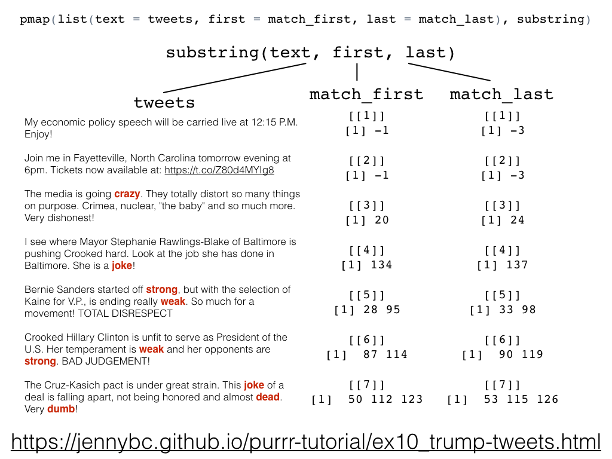

### Get to know your Awkward List

How long are the elements of `matches`?

```r
lengths(matches)                      # just happens to exist for length
```

```
## [1] 1 1 1 1 2 2 3
```

```r
sapply(matches, length)               # NSFP = not safe for programming
```

```
## [1] 1 1 1 1 2 2 3
```

```r
vapply(matches, length, integer(1))   # preferred base approach
```

```
## [1] 1 1 1 1 2 2 3
```

```r
map_int(matches, length)              # purrr way
```

```
## [1] 1 1 1 1 2 2 3
```

Exercise: Get a list of the match lengths.

Each element of matches carries this information in an attribute named match.length(). Store this info in a list called match_length.

- Pick one nontrivial example, e.g. m <- matches[[7]].
- Get the attribute named match.length. Hint: attr().
- Drop that approach into purrr::map() to scale up to the full matches list.

Here’s how to do that for the last element of matches:

```r
m <- matches[[7]]
attr(m, which = "match.length")
```

```
## [1] 4 4 4
```

Different ways to apply this logic to the entire matches list.

1 Pre-defined custom function. Conceptually simplest? Most verbose.

```r
ml <- function(x) attr(x, which = "match.length")
map(matches, ml)
```

```
## [[1]]
## [1] -1
##
## [[2]]
## [1] -1
##
## [[3]]
## [1] 5
##
## [[4]]
## [1] 4
##
## [[5]]
## [1] 6 4
##
## [[6]]
## [1] 4 6
##
## [[7]]
## [1] 4 4 4
```

2 Anonymous function. More abstract? Very compact.

```r
map(matches, ~ attr(.x, which = "match.length"))
```

```
## [[1]]
## [1] -1
##
## [[2]]
## [1] -1
##
## [[3]]
## [1] 5
##
## [[4]]
## [1] 4
##
## [[5]]
## [1] 6 4
##
## [[6]]
## [1] 4 6
##
## [[7]]
## [1] 4 4 4
```

3 Pre-existing function, additional arguments passed via `...`.

```r
(match_length <- map(matches, attr, which = "match.length"))
```

```
## [[1]]
## [1] -1
##
## [[2]]
## [1] -1
##
## [[3]]
## [1] 5
##
## [[4]]
## [1] 4
##
## [[5]]
## [1] 6 4
##
## [[6]]
## [1] 4 6
##
## [[7]]
## [1] 4 4 4
```

It’s good to know about all 3 approaches. Exercise: Count the number of Trump Android words in each tweet.

Let’s compute how many Trump Android words appear in each tweet.

This isn’t quite lengths(matches), though, is it? Think about those -1s. Sad.

- Pick two examples at the extremes: a tweet with 0 Trump words and another with 3.
- Write some code that takes the associated element of matches and returns 0 or 3, as appropriate.
- Use one of the approaches above to insert this into purrr::map() and apply to matches.

Code that works for both extreme examples:

```r
m <- matches[[1]]
sum(m > 0)
```

```
## [1] 0
```

```r
m <- matches[[7]]
sum(m > 0)
```

```
## [1] 3
```

Insert into the machinery:

```r
f <- function(x) sum(x > 0)
map(matches, f)
```

```
## [[1]]
## [1] 0
##
## [[2]]
## [1] 0
##
## [[3]]
## [1] 1
##
## [[4]]
## [1] 1
##
## [[5]]
## [1] 2
##
## [[6]]
## [1] 2
##
## [[7]]
## [1] 3
```

```r
map(matches, ~ sum(.x > 0))
```

```
## [[1]]
## [1] 0
##
## [[2]]
## [1] 0
##
## [[3]]
## [1] 1
##
## [[4]]
## [1] 1
##
## [[5]]
## [1] 2
##
## [[6]]
## [1] 2
##
## [[7]]
## [1] 3
```

Note that only 2 of the 3 approaches are workable here. That’s why it’s nice to know all of them.

What is the resulting object? What would be a simpler form of the same info? Read the help on map_int() and its other type-specific friends. Tweak your existing approach to return an integer vector, with length equal to the number of tweets.

```r
map_int(matches, ~ sum(.x > 0))
```

```
## [1] 0 0 1 1 2 2 3
```

Confirm that this is, indeed, different from just taking the lengths of the elements of matches:

```r
tibble(
  naive_length = lengths(matches),
  n_words = map_int(matches, ~ sum(.x > 0))
)
```

```
## # A tibble: 7 x 2
##   naive_length n_words
##          <int>   <int>
## 1            1       0
## 2            1       0
## 3            1       1
## 4            1       1
## 5            2       2
## 6            2       2
## 7            3       3
```

### Strip the attributes from matches

Exercise!

We have safely stored the match lengths in match_length.

Let’s create an almost-copy of matches and call it match_first. How will it differ? Remove the attributes from the elements of matches, so there’s less clutter when we print.

Hint: as.vector() will strip attributes.

```r
(match_first <- map(matches, as.vector))
```

```
## [[1]]
## [1] -1
##
## [[2]]
## [1] -1
##
## [[3]]
## [1] 20
##
## [[4]]
## [1] 134
##
## [[5]]
## [1] 28 95
##
## [[6]]
## [1]  87 114
##
## [[7]]
## [1]  50 112 123
```

### Assess progress in a small example

Use the R objects on hand to achieve our goal in a small example: extract Trump words from single tweet. Work on tweets #1 and #7 because they represent the two extremes, 0 and 3 words respectively. If you can handle them, you’re in good shape.

Relevant R objects:

```r
tweets %>% strtrim(70)
```

```
## [1] "My economic policy speech will be carried live at 12:15 P.M. Enjoy!"
## [2] "Join me in Fayetteville, North Carolina tomorrow evening at 6pm. Ticke"
## [3] "The media is going crazy. They totally distort so many things on purpo"
## [4] "I see where Mayor Stephanie Rawlings-Blake of Baltimore is pushing Cro"
## [5] "Bernie Sanders started off strong, but with the selection of Kaine for"
## [6] "Crooked Hillary Clinton is unfit to serve as President of the U.S. Her"
## [7] "The Cruz-Kasich pact is under great strain. This joke of a deal is fal"
```

```r
match_first
```

```
## [[1]]
## [1] -1
##
## [[2]]
## [1] -1
##
## [[3]]
## [1] 20
##
## [[4]]
## [1] 134
##
## [[5]]
## [1] 28 95
##
## [[6]]
## [1]  87 114
##
## [[7]]
## [1]  50 112 123
```

```r
match_length
```

```
## [[1]]
## [1] -1
##
## [[2]]
## [1] -1
##
## [[3]]
## [1] 5
##
## [[4]]
## [1] 4
##
## [[5]]
## [1] 6 4
##
## [[6]]
## [1] 4 6
##
## [[7]]
## [1] 4 4 4
```

Start with tweet #7, with 3 Trump words.

```r
(tweet <- tweets[7])
```

```
## [1] "The Cruz-Kasich pact is under great strain. This joke of a deal is falling apart, not being honored and almost dead. Very dumb!"
```

```r
(t_first <- match_first[[7]])
```

```
## [1]  50 112 123
```

```r
(t_length <- match_length[[7]])
```

```
## [1] 4 4 4
```

```r
(t_last <- t_first + t_length - 1)
```

```
## [1]  53 115 126
```

```r
substring(tweet, t_first, t_last)
```

```
## [1] "joke" "dead" "dumb"
```

How well does this code work for tweet #1, with 0 Trump words?

```r
(tweet <- tweets[1])
```

```
## [1] "My economic policy speech will be carried live at 12:15 P.M. Enjoy!"
```

```r
(t_first <- match_first[[1]])
```

```
## [1] -1
```

```r
(t_length <- match_length[[1]])
```

```
## [1] -1
```

```r
(t_last <- t_first + t_length - 1)
```

```
## [1] -3
```

```r
substring(tweet, t_first, t_last)
```

```
## [1] ""
```

There is some nonsense along the way and we get an empty string. I’d rather get character(0) or NA_character_ back, but I can live with this.

But we’re in good shape. We just need to compute where the matches end for all matches. Store where Trump words end

Make a list that holds where the Trump words end. Call it match_last.

Pseudo-code for how we did this for a single tweet:

first <- an element of matches length <- an element of match_length last <- first + length - 1

This is another map()-type problem, but instead of mapping over one list, we need to map over 2 lists in parallel.

Read the help for purrr::map2()!

Here’s the usage: map2(.x, .y, .f, …)

Match this up to our task:

- Input 1 = .x will be first
- Input 2 = .y will be length
- Function .f will be something that does first + length - 1. Either a custom pre-defined function or an anonymous function. Your call.

Do it!

```r
(match_last <- map2(match_first, match_length, ~ .x + .y - 1))
```

```
## [[1]]
## [1] -3
##
## [[2]]
## [1] -3
##
## [[3]]
## [1] 24
##
## [[4]]
## [1] 137
##
## [[5]]
## [1] 33 98
##
## [[6]]
## [1]  90 119
##
## [[7]]
## [1]  53 115 126
```

### Extract the Trump words

We’re ready to put everything together.

Pseudo-code for how we do this for a single tweet:

text <- an element of tweets first <- an element of match_first last <- an element of match_last substring(text, first, last)

This is another map()-type problem, but instead of mapping over one list, we need to map over 3 lists in parallel.

There is no map3(). This calls for pmap(). Read the help on it!

Here’s the usage:

pmap(.l, .f, …)

How does this relate to our task?

- .l is a list of lists = the 3 lists we need to work through in parallel
  - list(text = tweets, first = match_first, last = match_last)
  - I deliberately choose the list names to match the argument names of substring(). Why confuse yourself? Why rely on position when you don’t have to?
- Function .f will be substring().

Do it!

```r
pmap(list(text = tweets, first = match_first, last = match_last), substring)
```

```
## [[1]]
## [1] ""
##
## [[2]]
## [1] ""
##
## [[3]]
## [1] "crazy"
##
## [[4]]
## [1] "joke"
##
## [[5]]
## [1] "strong" "weak"
##
## [[6]]
## [1] "weak"   "strong"
##
## [[7]]
## [1] "joke" "dead" "dumb"
```

We did it!

#### March through the rows in a data frame

Remember that a data frame is, in fact, a list of equal-length vectors. Just like the .l argument of pmap(). So often it’s nice to work your problems in the context of a data frame, instead of using free-floating vectors or lists. Why?

- It’s safer. This makes it very hard for you to subset or reorder one of the pieces and forget to do the same to the others.
- It’s tidier. Your project is contained in one neat object. You can print it, View() it, str(), etc. to get a sense of how things stand. This is more annoying if stuff is lying around in separate objects, so you’re less likely to catch problems quickly.

How would we do that post hoc here?

```r
mdf <- tibble(
  text = tweets,
  first = match_first,
  last = match_last
)
pmap(mdf, substring)
```

```
## [[1]]
## [1] ""
##
## [[2]]
## [1] ""
##
## [[3]]
## [1] "crazy"
##
## [[4]]
## [1] "joke"
##
## [[5]]
## [1] "strong" "weak"
##
## [[6]]
## [1] "weak"   "strong"
##
## [[7]]
## [1] "joke" "dead" "dumb"
```

Yes, it all boils down to this.